# Neural estimation for a Gaussian process

2025-10-29

## Introduction

We will be using Google Colab to build a neural estimator for the range parameter of a Gaussian process with a squared exponential kernel. First, go to https://colab.research.google.com/. Click File -> New notebook in Drive, and then change the runtime to R (Runtime -> Change runtime type, then pick R in the dropdown). We will not be using GPUs, so keep the CPU box checked.

# Installation

To install Keras3, run the following code. Colab already has Python and Tensorflow modules installed, so we do not need to do anything particularly complicated here.

```r
remotes::install_github("rstudio/tensorflow")
```

```r
install.packages("keras3")
library(keras3)
library(ggplot2)
```

Set seed for reproducibility.

```r
set_random_seed(1)
```

## Data import and pre-processing

Loading up the weather data we have been using so far

```r
file_url <- "https://github.com/reetamm/AI4stats/blob/main/weather.RDS?raw=true"
weather <- readRDS(url(file_url))
head(weather)
```

Subsetting the `tmax` data for January, and following up with a very crude plot.

```r
weatherJan <- weather[weather$month==1 & weather$lat == weather$lat[1],]
years <- lubridate::year(weatherJan$time)
head(weatherJan)
```

```
##                   time      lat    lon     tmax        pr month loc
## 1  1951-01-01 00:00:00 34.39791 248.75 277.2229 7.8160711     1   1
## 2  1951-01-01 00:00:00 34.39791 250.00 277.0520 9.4939730     1   2
## 3  1951-01-01 00:00:00 34.39791 251.25 277.1778 5.2872553     1   3
## 4  1951-01-01 00:00:00 34.39791 252.50 279.7752 3.3236256     1   4
## 5  1951-01-01 00:00:00 34.39791 253.75 281.2470 0.1392882     1   5
## 26 1951-01-02 00:00:00 34.39791 248.75 275.6317 0.0000000     1   1
```

```r
dim(weatherJan)
```

```
## [1] 9920    7
```

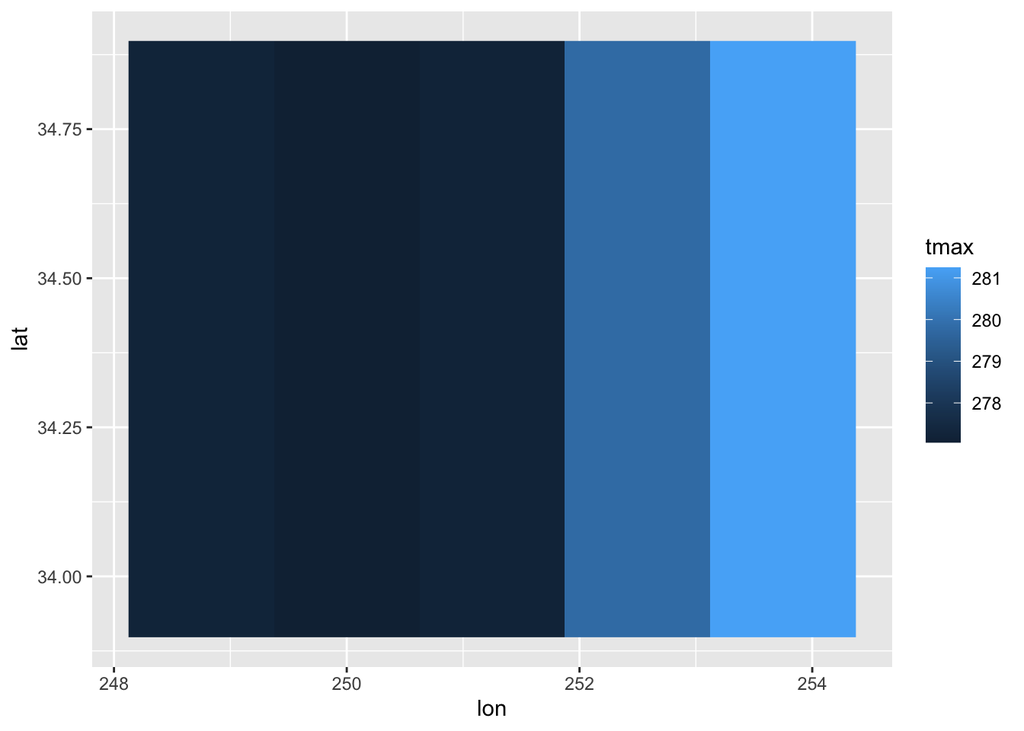

```r
ggplot(weatherJan[1:5,],aes(x=lon,y=lat,fill=tmax)) + geom_raster()
```

We could stick with the original coordinates but I’ll scale it because I have a better sense of what the range (lengthscale for the ML people) parameter should be if I have the distances on (0,1) . We first calculate the distance matrix.

```r
coords <- weatherJan[1:5,3]
coords_scaled <- (coords - min(coords))/diff(range(coords))
d = abs(outer(coords_scaled,coords_scaled,"-")) # compute distance matrix, d_{ij} = |x_i - x_j|
```

Then set a prior on the dependence parameter, here denoted by $\rho$. I’m just generating them from a $Unif(0,0.5)$

```r
K <- 50000
n <- 64

rho_train = runif(K,0,0.5) # length scale
```

Now, generate some training data. We use $n=64$ replicates as this will coincide with the number of observations we have.

We select the data to be on uniform margins using `pnorm`; but we could stick with any arbitrary margin.

```r
gp_val <- function(l,d,n){
    y <- matrix(NA,length(l),n*5)
    for(i in 1:length(l)){
        Sigma_SE = exp(-d^2/(2*l[i]^2)) # squared exponential kernel
        y[i,] = c(mvtnorm::rmvnorm(n,sigma=Sigma_SE))
    }
return(y)
}
x <- pnorm(gp_val(rho_train,d,n))

dim(x)
```

```
## [1] 50000   320
```

## Build the estimator

```r
model <- keras_model_sequential()

model %>%
    layer_dense(units = 256, activation = 'relu') %>%

    layer_dense(units = 128, activation = 'relu') %>%

    layer_dense(units = 64, activation = 'relu') %>%

    layer_dense(units = 1, activation = 'sigmoid')
```

Now, compile the model with a loss function and an optimizer. Here we use Adam with standard hyper-parameters, and the MSE loss function to target the posterior mean.

```r
model %>% compile(
    optimizer = "adam",
    loss = "mean_squared_error"
)
```

I’m going to keep a checkpoint as well as early stopping (somewhat overkill, but just showing that you *can* have multiple options).

```r
checkpoint <- callback_model_checkpoint(
  paste0("checkpoints/gp.weights.h5"),
  monitor = "val_loss",
  verbose = 0,
  save_best_only = TRUE,
  save_weights_only = TRUE,
  mode = "min",
  save_freq = "epoch"
)

early.stopping <-   callback_early_stopping(monitor = "val_loss", patience = 10)
```

If you choose to cancel training (ctrl + C, or the big red stop button), then the current model state will be saved and accessible.

```r
history <- model %>% fit(
    x = x,
    y = as.matrix(rho_train),
    callbacks = list(early.stopping,checkpoint),
    epochs = 100,
    verbose = 0,
    validation_split = 0.2,
    shuffle = T
)
```

Plot the training history, and print the summary of the architecture.

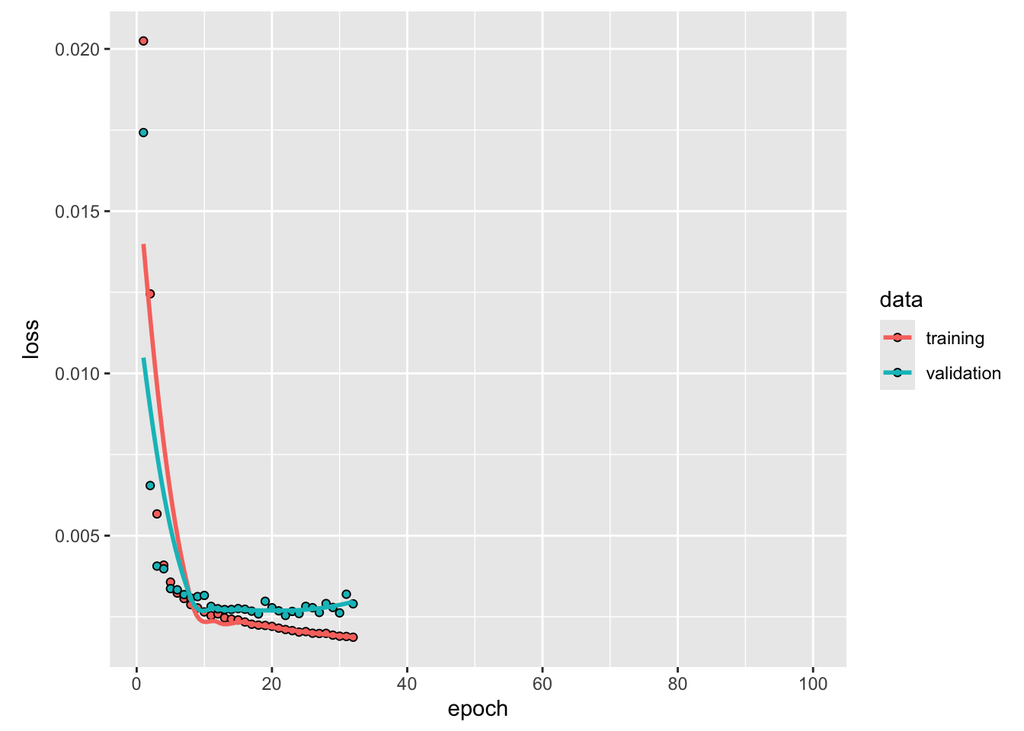

```r
plot(history)
```

```r
summary(model)
```

```
## Model: "sequential"
## ┏━━━━━━━━━━━━━━━━━━━━━━━━━━━━━━━━━━━┳━━━━━━━━━━━━━━━━━━━━━━━━━━┳━━━━━━━━━━━━━━━┓
## ┃ Layer (type)                      ┃ Output Shape             ┃       Param # ┃
## ┡━━━━━━━━━━━━━━━━━━━━━━━━━━━━━━━━━━━╇━━━━━━━━━━━━━━━━━━━━━━━━━━╇━━━━━━━━━━━━━━━┩
## │ dense (Dense)                     │ (32, 256)                │        82,176 │
## ├───────────────────────────────────┼──────────────────────────┼───────────────┤
## │ dense_1 (Dense)                   │ (32, 128)                │        32,896 │
## ├───────────────────────────────────┼──────────────────────────┼───────────────┤
## │ dense_2 (Dense)                   │ (32, 64)                 │         8,256 │
## ├───────────────────────────────────┼──────────────────────────┼───────────────┤
## │ dense_3 (Dense)                   │ (32, 1)                  │            65 │
## └───────────────────────────────────┴──────────────────────────┴───────────────┘
##  Total params: 370,181 (1.41 MB)
##  Trainable params: 123,393 (482.00 KB)
##  Non-trainable params: 0 (0.00 B)
##  Optimizer params: 246,788 (964.02 KB)
```

Let us load the best model back up.

```r
model <- load_model_weights(model,
                                 filepath = paste0("checkpoints/gp.weights.h5"))
```

Now, let’s see how well the estimator performs. We generate 1000 test datasets and compare the true values of $\rho$ with the predictions.

```r
K.test <- 1000
rho_test <- runif(K.test,0,0.5)

x.test <- pnorm(gp_val(rho_test,d,n))

predictions <- model %>% predict(x.test)
```

```
## 32/32 - 0s - 1ms/step
```

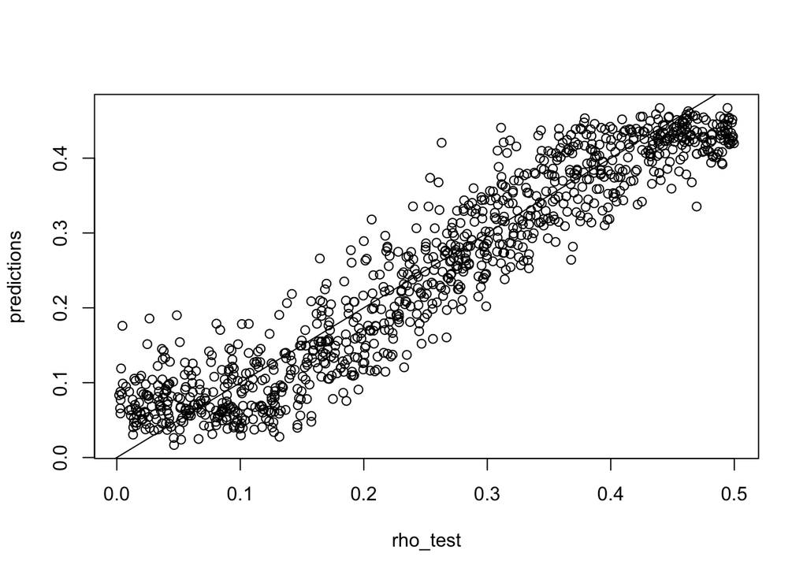

```r
plot(rho_test, predictions)
abline(a = 0, b = 1)
```

## Estimation for tmax data

I calculate the monthly mean for each year. This would do better with a Gaussian process than just using the maxima.

```r
weather3 <- aggregate(weatherJan$tmax,by=list(weatherJan$loc,years),FUN=mean)
```

Need to put the data in the same form as the training data, and then scale it. We could fit a parametric/semiparametric model to transform the data to Uniform, but I’m doing the simplest thing in the form of a Z-transform and using `pnorm` on it.

and then we can just estimate $\rho$ for our data.

```r
x.test <- matrix(c(weather3[,3]),nrow = 1)
x.test <- pnorm((x.test-mean(x.test))/sd(x.test))
model %>% predict(x.test)
```

```
## 1/1 - 0s - 10ms/step
```

```
##            [,1]
## [1,] 0.09228949
```